# HSPA_Classififcation

## Project Topic:

### Identifying the most critical Health Professional Shortage Areas (HPSAs) to serve the patients effectively and efficiently.

### Objective:

While HRSA works at most of the healthcare disciplines, we have planned to focus only on Primary Health Care, Dental Health Care and Mental Health Care disciplines and understand the contributing factors in generalizing the shortage areas.

### Motivation:

Making use of Health providers in an efficient way brings out a phenomenal outcome to save the life of many in some of the health provider shortage areas. There can be areas like low-income people, geographically isolated, high Medicare requirement and such. To achieve this, analytics must be developed in an agile manner to keep pace with the changing needs of high quality and performance improvement initiatives. This has led us to come up with a data product by recruiting /distributing available health providers to assist those needy people.

### About Dataset

Health workforce shortage areas are geographic areas, populations, and facilities that have a shortage of outpatient primary care, dental, and mental health providers and services. These areas are designated by the Health Resources and Services Administration (HRSA), a federal agency in the United States Department of Health and Human Services. There are several types of shortage designations including:

• Health Professional Shortage Areas (HPSAs)

• Medically Underserved Areas and Populations (MUAPs)

• Exceptional Medically Underserved Population (Exceptional MUPs)

• Governor's-Designated Secretary-Certified Shortage Areas for Rural Health Clinics

HRSA's Bureau of Health Workforce operates a cooperative agreement and evaluates applications submitted by the Primary Care Office (PCO) of each U.S. state and territory as part of the process to designate some types of shortage areas. These applications are reviewed by HRSA to determine if they meet specific designation criteria which differs by the type of shortage area. Other shortage area types are automatically designated by federal statute or at the request of a state governor. Once HPSAs are designated, score is calculated which represents a relative measure of need for health care services for that discipline. Both HPSAs and MUAPs can be designated to indicate a shortage of primary care services while only HPSAs can be designated to indicate a shortage of dental or mental health services. Shortage area designations and scores are used by various federal programs for distributing resources. Some shortage area designations may also be used by state programs. See the shortage designation website for more information.

All three file contain the same columns but represent only a single healthcare discipline. Each record represents either a "component" (county, county subdivision or census tract) of a Geographic/Population HPSA service area or represents the physical location of facility HPSA.

Files: • BCD_HPSA_FCT_DET_PC.csv: Primary Care HPSAs

• BCD_HPSA_FCT_DET_DH.csv: Dental Health HPSAs

• BCD_HPSA_FCT_DET_MH.csv: Mental Health HPSAs

All these above three files are merged into one file in excel and imported them.

HPSA_Healthcare.xlsx

```python
# Import all the libraries
import numpy as np # numerical calculations
import pandas as pd # data processing, CSV file I/O (e.g. pd.read_csv)

import matplotlib.pyplot as plt#visualization
from PIL import  Image
%matplotlib inline


import seaborn as sns#visualization

import warnings
warnings.filterwarnings("ignore")

import plotly.offline as py #visualization
py.init_notebook_mode(connected=True) #visualization
import plotly.graph_objs as go #visualization
import plotly.subplots as sp  #visualization
import plotly.figure_factory as ff#visualization
import datetime # to work with dates
```

```python
from google.colab import drive
drive.mount('/content/drive')
```

# Data Import

```python
hpsa= pd.read_excel('/content/drive/MyDrive/Colab Notebooks/HPSA_Healthcare.xlsx', sheet_name='hpsa_data')
```

# Data Overview

```python
hpsa.info()
```

```
<class 'pandas.core.frame.DataFrame'>
RangeIndex: 126387 entries, 0 to 126386
Data columns (total 65 columns):
 #   Column                                                                    Non-Null Count   Dtype
---  ------                                                                    --------------   -----
 0   HPSA Name                                                                 126387 non-null  object
 1   HPSA ID                                                                   126387 non-null  object
 2   Designation Type                                                          126387 non-null  object
 3   HPSA Discipline Class                                                     126387 non-null  object
 4   HPSA Score                                                                126387 non-null  int64
 5   Primary State Abbreviation                                                126387 non-null  object
 6   HPSA Status                                                               126387 non-null  object
 7   HPSA Designation Date                                                     126387 non-null  object
 8   HPSA Designation Last Update Date                                         126387 non-null  object
 9   Metropolitan Indicator                                                    126387 non-null  object
```

[output cut: 57 more lines]

```python
hpsa.columns = hpsa.columns.str.replace(' ','_')
```

```python
# display number of rows and columns
print ("Rows     : " ,hpsa.shape[0])
print ("Columns  : " ,hpsa.shape[1])
```

```
Rows     :  126387
Columns  :  65
```

```python
hpsa.head(5)
```

|  | HPSA_Name | HPSA_ID | Designation_Type | HPSA_Discipline_Class | HPSA_Score | Primary_State_Abbreviation | HPSA_Status | HPSA_Designation_Date | HPSA_Designation_Last_Update_Date | Metropolitan_Indicator | ... | Provider_Type | Rural_Status_Code | State_Abbreviation | State_and_County_Federal_Information_Processing_Standard_Code | State_FIPS_Code | State_Name | U.S._-_Mexico_Border_100_Kilometer_Indicator | U.S._-_Mexico_Border_County_Indicator | Data_Warehouse_Record_Create_Date | Data_Warehouse_Record_Create_Date_Text |
| --- | --- | --- | --- | --- | --- | --- | --- | --- | --- | --- | --- | --- | --- | --- | --- | --- | --- | --- | --- | --- | --- |
| 0 | Cowlitz Tribal Behavioral Health - Annex | 6538508989 | Indian Health Service, Tribal Health, and Urba... | Dental Health | 15 | WA | Designated | 08/18/2019 | 09/12/2021 | Unknown | ... | NaN | N | WA | 53015 | 53 | Washington | N | N | 03/20/2022 | 2022-03-20 |
| 1 | CONFLUENCE HEALTH ROYAL CITY | 6538433371 | Rural Health Clinic | Dental Health | 13 | WA | Designated | 08/18/2019 | 09/11/2021 | Unknown | ... | NaN | R | WA | 53025 | 53 | Washington | N | N | 03/20/2022 | 2022-03-20 |
| 2 | West Clallam and West Jefferson Counties | 6538432701 | Geographic HPSA | Dental Health | 20 | WA | Designated | 07/28/2017 | 09/10/2021 | Unknown | ... | Not Applicable | R | WA | 53031 | 53 | Washington | N | N | 03/20/2022 | 2022-03-20 |
| 3 | West Clallam and West Jefferson Counties | 6538432701 | Geographic HPSA | Dental Health | 20 | WA | Designated | 07/28/2017 | 09/10/2021 | Unknown | ... | Not Applicable | R | WA | 53009 | 53 | Washington | N | N | 03/20/2022 | 2022-03-20 |
| 4 | West Clallam and West Jefferson Counties | 6538432701 | Geographic HPSA | Dental Health | 20 | WA | Designated | 07/28/2017 | 09/10/2021 | Unknown | ... | Not Applicable | R | WA | 53009 | 53 | Washington | N | N | 03/20/2022 | 2022-03-20 |

5 rows × 65 columns

# Overview of key points on HPSA

#### Health Provider Disciplines

##### Primary Care:

Identifies within an area that there is insufficient access to primary care physicians (M.D. and D.O.) that primarily practice in one of the following specialties: family practice, general practice, internal medicine, pediatrics, OB/GYN, and general geriatrics. A population-to-provider ratio based on the number of provider FTEs (full time equivalents, 1 FTE = 40 hours of direct patient care per week) is used to determine eligibility.

##### Dental:

Identifies an area’s access to dental care. Unlike the Primary Care and Mental Health HPSAs, dental provider FTEs (full time equivalents) are calculated by weighting the number of patient care hours provided by a dentist (general and pediatric) per week by the dentist’s age and the number of assistants the dentist employs.

##### Mental Health:

Identifies an area’s access to either psychiatrists only, or core mental health professionals (CMHPs) which include psychiatrists, clinical psychologists, clinical social workers, psychiatric nurse specialists, and marriage and family therapists.

###### HPSA Sub-Categories:

Each type of HPSA (Primary Care, Dental, Mental Health) must be categorized into one of the following categories. Each category has a different set of qualifying criteria.

Geographic: This designation demonstrates a shortage for the total population of an area.

Population Group: This designation demonstrates a shortage of providers for population groups.

A population group must be one of the following:

• Low-income populations (greater than 30% of population with incomes at or below 200% of the federal poverty level)

• Migrant and/or seasonal farmworkers and families

• Medicaid - eligible

• Native Americans/Native Alaskan

• Homeless Populations

• Other populations isolated from access by means of a specified language, cultural barriers, or handicaps Facility: This designation is only for facilities including community health centers, rural health clinics, federal correctional facilities, and state hospitals. Some of the factors used to evaluate a facility’s designation eligibility are outpatient census, wait times, patients’ residences, and in-house faculty.

#### HPSA Scoring

The federal Shortage Designation Branch calculates a score (0- to 25 for primary care and mental health and 0 to 26 for dental) with 25 / 26 being the highest degree of shortage for each designated HPSA. The score is used to prioritize areas of greatest need for National Health Service Corps placements. Each HPSA application is evaluated and scored based on the following criteria.

A population-to-provider ratio based on the number of provider FTEs (full time equivalents, 1 FTE = 40 hours of direct patient care per week) is used to determine eligibility.

#### Population to Provider Ratio

HPSA Geographic Population Geo w/ High Need

Primary Care 3,500:1 3,000:1 3,000:1 Dental 5,000:1 4,000:1 4,000:1 Mental Health  
1) Psychiatrists 30,000:1 20,000:1 20,000:1 2) CMHP 9,000:1 6,000:1 6,000:1 3) Psychiatrists and CMHP 6,000:1 4,500:1 4,500:1

### HPSA calculations

1) Estimated Served Population– we know them through census……… example: 4200

2) Population to provider ratio – : example PC for geographic = 3500:1

3) HPSA FTE (Full time Equivalent) 3500:1, 4200:? = 1.2 (meaning for population who are being currently served, for them the available HP is 1.2)

4) HPSA Estimated Underserved Population  
HPSA Designation Population– Estimated Served Population = 8986-4200 = 4786

5) HPSA Shortage 3500:1, 4786:? = 1.36 ==1.4 (meaning for population who are not being currently served, for them the required HP is 1.4)

6) HPSA Formal Ratio HPSA Designation Population/HPSA FTE

8) HPSA Degree of Shortage This attribute represents the degree of practitioner shortage for the Health Professional Shortage Area (HPSA) based on population to provider ratio. General understanding is : quantity demanded (Qd) > quantity supplied (Qs).

# Data Cleaning

```python
#Using excel, initial screening & necessity of the columns is evaluated and now we are droppoing those columns here.
hpsa=hpsa.drop(['Primary_State_Abbreviation',
                'HPSA_Designation_Date',
                'Metropolitan_Indicator',
                'HPSA_Geography_Identification_Number',
                'HPSA_Degree_of_Shortage',
                'Withdrawn_Date',
                'Primary_HHS_Region_Name',
                'Longitude',
                'Latitude',
                'BHCMIS_Organization_Identification_Number',
                'Break_in_Designation',
                'Common_County_Name',
                'Common_State_Name',
                'Common_Postal_Code',
                'Common_Region_Name',
                'Common_State_Abbreviation',
                'Common_State_County_FIPS_Code',
                'Common_State_FIPS_Code',
                'HPSA_City',
                'HPSA_Formal_Ratio',
                'County_Equivalent_Name',
                'County_or_County_Equivalent_Federal_Information_Processing_Standard_Code',
                'Discipline_Class_Number',
                'HPSA_Address',
                'HPSA_Component_Name',
                'HPSA_Component_Source_Identification_Number',
                'HPSA_Component_State_Abbreviation',
                'HPSA_Component_Type_Code',
                'HPSA_Component_Type_Description',
                'HPSA_Resident_Civilian_Population',
                'HPSA_Metropolitan_Indicator_Code',
                'HPSA_Population_Type_Code',
                'HPSA_Designation_Population_Type_Description',
                'HPSA_Postal_Code',
                'HPSA_Status_Code',
                'HPSA_Type_Code',
                'HPSA_Withdrawn_Date_String',
                'Primary_State_FIPS_Code',
                'Primary_State_Name',
                'Rural_Status_Code',
                'State_Abbreviation',
                'State_and_County_Federal_Information_Processing_Standard_Code',
                'State_FIPS_Code',
                'Data_Warehouse_Record_Create_Date',
                'Data_Warehouse_Record_Create_Date_Text'], axis = 1)
```

```python
print ("Rows     : " ,hpsa.shape[0])
print ("Columns  : " ,hpsa.shape[1])
# see how many unique values are in each column
print ("\nNumber of Unique values :  \n",hpsa.nunique())
```

```
Rows     :  126387
Columns  :  20

Number of Unique values :
 HPSA_Name                                       18724
HPSA_ID                                         35006
Designation_Type                                   10
HPSA_Discipline_Class                               3
HPSA_Score                                         27
HPSA_Status                                         3
HPSA_Designation_Last_Update_Date                2062
HPSA_FTE                                         3588
HPSA_Designation_Population                     17286
%_of_Population_Below_100%_Poverty                537
HPSA_Population_Type                               14
Rural_Status                                        5
HPSA_Estimated_Served_Population                 4182
HPSA_Estimated_Underserved_Population           11268
HPSA_Provider_Ratio_Goal                           17
HPSA_Shortage                                    3959
Provider_Type                                       4
State_Name                                         59
U.S._-_Mexico_Border_100_Kilometer_Indicator        3
U.S._-_Mexico_Border_County_Indicator               3
dtype: int64
```

```python
#cheque for unique values
print(hpsa['HPSA_Score'].unique())
# mapping 26 as 25 as rank 25 and 26 can fairly treated to be nearly equal
hpsa['HPSA_Score'] = [25 if x==26 else x for x in hpsa['HPSA_Score']]
hpsa['HPSA_Score'].unique()
```

```
[15 13 20 11 16 21 17 18  7 19 14 12 24  9  0 10 26 25  1 23  5 22  6  3
  8  4  2]
```

```
array([15, 13, 20, 11, 16, 21, 17, 18,  7, 19, 14, 12, 24,  9,  0, 10, 25,
        1, 23,  5, 22,  6,  3,  8,  4,  2])
```

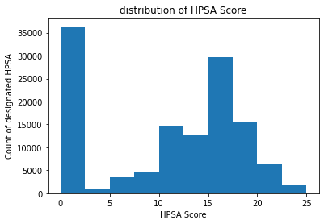

```python
import matplotlib.pyplot as plt
plt.hist(x=hpsa['HPSA_Score'])
plt.title('distribution of HPSA Score')
plt.xlabel('HPSA Score')
plt.ylabel('Count of designated HPSA')
plt.show()
```

```python
#cheque for unique values
print(hpsa['Rural_Status'].unique())
hpsa['Rural_Status'].replace('', np.nan, inplace=True)
# Replacing ' NaN' with 'Not Applicable' since those values are not belonging to any rural creteria
hpsa['Rural_Status'] = hpsa['Rural_Status'].replace(np.nan, "Not Applicable")
hpsa['Rural_Status'].unique()
```

```
['Non-Rural' 'Rural' 'Partially Rural' nan 'Unknown' 'Not Applicable']
```

```
array(['Non-Rural', 'Rural', 'Partially Rural', 'Not Applicable',
       'Unknown'], dtype=object)
```

```python
print(hpsa['HPSA_Designation_Last_Update_Date'])
#Covert date column to datetime format as we found from info() that the date data type is of object
hpsa['HPSA_Designation_Last_Update_Date'] = pd.to_datetime(hpsa['HPSA_Designation_Last_Update_Date']).dt.strftime("%Y%m%d")
hpsa['HPSA_Designation_Last_Update_Date'] = pd.to_numeric(hpsa['HPSA_Designation_Last_Update_Date'])
print(hpsa['HPSA_Designation_Last_Update_Date'])
```

```
0         09/12/2021
1         09/11/2021
2         09/10/2021
3         09/10/2021
4         09/10/2021
             ...
126382    12/28/2021
126383    03/14/2022
126384    12/28/2021
126385    09/11/2021
126386    02/18/2022
Name: HPSA_Designation_Last_Update_Date, Length: 126387, dtype: object
0         20210912
1         20210911
2         20210910
3         20210910
4         20210910
            ...
126382    20211228
126383    20220314
126384    20211228
126385    20210911
126386    20220218
Name: HPSA_Designation_Last_Update_Date, Length: 126387, dtype: int64
```

```python
#fill blanks with '0' for population column since we do not know the population and full time equivalent of HP is also zero.
hpsa['HPSA_Designation_Population'].replace('', np.nan, inplace=True)
print(hpsa['HPSA_Designation_Population'].isna())
hpsa.dropna(subset=['HPSA_Designation_Population'], inplace=True)
hpsa.drop(hpsa[hpsa['HPSA_Designation_Population'] == 0].index, inplace = True) # we cant work on where population is unkown
```

```
0         False
1         False
2         False
3         False
4         False
          ...
126382    False
126383    False
126384    False
126385    False
126386    False
Name: HPSA_Designation_Population, Length: 126387, dtype: bool
```

```python
#cheque for unique values
print(hpsa['HPSA_Status'].unique())
# Replacing 'Proposed For Withdrawal' as 'Withdrawn'
hpsa['HPSA_Status']= hpsa['HPSA_Status'].replace("Proposed For Withdrawal", "Withdrawn")
print(hpsa['HPSA_Status'].unique())
```

```
['Designated' 'Withdrawn' 'Proposed For Withdrawal']
['Designated' 'Withdrawn']
```

```python
# for few records,Full time equivalent of health provider is not given, But we know their population.
# if there are no Full time equivalent of health provider,we will map the served population as'0'.
# Underserved population is now the diffrence between total and served population
hpsa['HPSA_FTE'].fillna(0, inplace=True)
hpsa.loc[hpsa['HPSA_FTE'] == 0,'HPSA_Estimated_Served_Population']=0
hpsa['HPSA_Estimated_Underserved_Population']= hpsa['HPSA_Designation_Population']-hpsa['HPSA_Estimated_Served_Population']
```

```python
hpsa
```

|  | HPSA_Name | HPSA_ID | Designation_Type | HPSA_Discipline_Class | HPSA_Score | HPSA_Status | HPSA_Designation_Last_Update_Date | HPSA_FTE | HPSA_Designation_Population | %_of_Population_Below_100%_Poverty | HPSA_Population_Type | Rural_Status | HPSA_Estimated_Served_Population | HPSA_Estimated_Underserved_Population | HPSA_Provider_Ratio_Goal | HPSA_Shortage | Provider_Type | State_Name | U.S._-_Mexico_Border_100_Kilometer_Indicator | U.S._-_Mexico_Border_County_Indicator |
| --- | --- | --- | --- | --- | --- | --- | --- | --- | --- | --- | --- | --- | --- | --- | --- | --- | --- | --- | --- | --- |
| 0 | Cowlitz Tribal Behavioral Health - Annex | 6538508989 | Indian Health Service, Tribal Health, and Urba... | Dental Health | 15 | Designated | 20210912 | 0.000 | 12898.0 | NaN | NaN | Non-Rural | 0.0 | 12898.0 | NaN | NaN | NaN | Washington | N | N |
| 1 | CONFLUENCE HEALTH ROYAL CITY | 6538433371 | Rural Health Clinic | Dental Health | 13 | Designated | 20210911 | 0.000 | 47190.0 | NaN | NaN | Rural | 0.0 | 47190.0 | NaN | NaN | NaN | Washington | N | N |
| 2 | West Clallam and West Jefferson Counties | 6538432701 | Geographic HPSA | Dental Health | 20 | Designated | 20210910 | 0.000 | 14515.0 | 21.5 | Geographic Population | Rural | 0.0 | 14515.0 | 1900-07-26 08:01:00 | 2.900 | Not Applicable | Washington | N | N |
| 3 | West Clallam and West Jefferson Counties | 6538432701 | Geographic HPSA | Dental Health | 20 | Designated | 20210910 | 0.000 | 14515.0 | 21.5 | Geographic Population | Rural | 0.0 | 14515.0 | 1900-07-26 08:01:00 | 2.900 | Not Applicable | Washington | N | N |
| 4 | West Clallam and West Jefferson Counties | 6538432701 | Geographic HPSA | Dental Health | 20 | Designated | 20210910 | 0.000 | 14515.0 | 21.5 | Geographic Population | Rural | 0.0 | 14515.0 | 1900-07-26 08:01:00 | 2.900 | Not Applicable | Washington | N | N |
| ... | ... | ... | ... | ... | ... | ... | ... | ... | ... | ... | ... | ... | ... | ... | ... | ... | ... | ... | ... | ... |
| 126382 | Pathway Home | 1026580907 | Indian Health Service, Tribal Health, and Urba... | Primary Care | 2 | Designated | 20211228 | 0.000 | 40901.0 | NaN | NaN | Non-Rural | 0.0 | 40901.0 | NaN | NaN | NaN | Alaska | N | N |
| 126383 | Aleutians West Borough | 1026580765 | Geographic HPSA | Primary Care | 10 | Designated | 20220314 | 1.500 | 5454.0 | 6.8 | Geographic Population | Rural | 5250.0 | 204.0 | 1900-05-24 20:01:00 | 0.060 | Not Applicable | Alaska | N | N |
| 126384 | ANTHC Education Development | 1026566409 | Indian Health Service, Tribal Health, and Urba... | Primary Care | 2 | Designated | 20211228 | 0.000 | 38910.0 | NaN | NaN | Non-Rural | 0.0 | 38910.0 | NaN | NaN | NaN | Alaska | N | N |
| 126385 | King Salmon Village Clinic | 1026548670 | Indian Health Service, Tribal Health, and Urba... | Primary Care | 5 | Designated | 20210911 | 0.000 | 390.0 | NaN | NaN | Rural | 0.0 | 390.0 | NaN | NaN | NaN | Alaska | N | N |
| 126386 | ME - Kenai Peninsula Borough | 1026530384 | HPSA Population | Primary Care | 13 | Designated | 20220218 | 2.476 | 21664.0 | 12.0 | Medicaid Eligible Population HPSA | Rural | 7428.0 | 14236.0 | 1900-05-04 00:01:00 | 4.744 | Not Applicable | Alaska | N | N |

112734 rows × 20 columns

```python
#print(hpsa['HPSA_Provider_Ratio_Goal'].unique())
#population to provider ratio datatype is displaying date format.Converting them into numeric will not solve the purpose
#Create new column and Map the population to provider ratio
conditions = [
    (hpsa['HPSA_Discipline_Class'] == "Dental Health") & (hpsa['Designation_Type']== "Geographic HPSA"),
    (hpsa['HPSA_Discipline_Class'] == "Dental Health") & (hpsa['Designation_Type']== "High Needs Geographic HPSA"),
    (hpsa['HPSA_Discipline_Class'] == "Dental Health") & (hpsa['Designation_Type']== "HPSA Population"),
    (hpsa['HPSA_Discipline_Class'] == "Primary Care")  & (hpsa['Designation_Type']== "Geographic HPSA"),
    (hpsa['HPSA_Discipline_Class'] == "Primary Care")  & (hpsa['Designation_Type']== "High Needs Geographic HPSA"),
    (hpsa['HPSA_Discipline_Class'] == "Primary Care")  & (hpsa['Designation_Type']== "HPSA Population"),
    (hpsa['HPSA_Discipline_Class'] == "Mental Health") & (hpsa['Designation_Type']== "Geographic HPSA") & (hpsa['Provider_Type']== "Psychiatrist"),
    (hpsa['HPSA_Discipline_Class'] == "Mental Health") & (hpsa['Designation_Type']== "Geographic HPSA")&(hpsa['Provider_Type']== "Core Mental Health"),
    (hpsa['HPSA_Discipline_Class'] == "Mental Health") & (hpsa['Designation_Type']== "Geographic HPSA")&(hpsa['Provider_Type']== "Psychiatrist / Core Mental Health"),
    (hpsa['HPSA_Discipline_Class'] == "Mental Health") & (hpsa['Designation_Type']== "High Needs Geographic HPSA")&(hpsa['Provider_Type']== "Psychiatrist"),
    (hpsa['HPSA_Discipline_Class'] == "Mental Health") & (hpsa['Designation_Type']== "High Needs Geographic HPSA")&(hpsa['Provider_Type']== "Core Mental Health"),
    (hpsa['HPSA_Discipline_Class'] == "Mental Health") & (hpsa['Designation_Type']== "High Needs Geographic HPSA")&(hpsa['Provider_Type']== "Psychiatrist / Core Mental Health"),
    (hpsa['HPSA_Discipline_Class'] == "Mental Health") & (hpsa['Designation_Type']== "HPSA Population")&(hpsa['Provider_Type']== "Psychiatrist"),
    (hpsa['HPSA_Discipline_Class'] == "Mental Health") & (hpsa['Designation_Type']== "HPSA Population")&(hpsa['Provider_Type']== "Core Mental Health"),
    (hpsa['HPSA_Discipline_Class'] == "Mental Health") & (hpsa['Designation_Type']== "HPSA Population")&(hpsa['Provider_Type']== "Psychiatrist / Core Mental Health")
    ]

# create a list of the values we want to assign for each condition
values = [5000,4000,4000,3500,3000,3000,30000,9000,6000,20000,6000,4500,20000,6000,4500]

# create a new column and use np.select to assign values to it using our lists as arguments
hpsa['Pop_Per_HP'] = np.select(conditions, values)
print(hpsa.shape)
# delete '0's in the new column.
hpsa.drop(hpsa[hpsa['Pop_Per_HP'] == 0].index, inplace = True)

#Every shortage area should have standard "population to provider ratio" .
#Only then we can calculate the shortage of providers and the scoring.
#Therfore we delete those records

# now drop the pupulation_provider_ratio column
hpsa=hpsa.drop(['HPSA_Provider_Ratio_Goal'],axis=1)
print(hpsa.shape)
```

```
(112734, 21)
(95199, 20)
```

```python
#Recalculate the shortage for all the records as we have right values for all the records.
hpsa['HPSA_Shortage']= hpsa['HPSA_Estimated_Underserved_Population']/hpsa['Pop_Per_HP']
```

```python
#hpsa['HPSA_FTE']
```

```python
#having problems with infinite values so the below code we are not executing


#Recalculate the formal ratio
#hpsa['HPSA_Formal_Ratio']= hpsa['HPSA_Designation_Population']/hpsa['HPSA_FTE']
#hpsa['HPSA_Formal_Ratio'].unique()

#hpsa['HPSA_Formal_Ratio']= hpsa['HPSA_Formal_Ratio'].replace([np.inf,-np.inf] , 0 ,inplace=True)
#hpsa['HPSA_Formal_Ratio']=hpsa['HPSA_Formal_Ratio'].replace(np.nan, 0,inplace=True)
#hpsa.loc[hpsa['HPSA_FTE'] != 0, 'HPSA_Formal_Ratio'] = hpsa['HPSA_Designation_Population']/hpsa['HPSA_FTE']
```

```python
#replace the 'blanks' with '0' for '%_of_Population_Below_100%_Poverty'
hpsa['%_of_Population_Below_100%_Poverty'].replace('', np.nan, inplace=True)
hpsa['%_of_Population_Below_100%_Poverty'].replace(np.nan, 0,inplace=True)
```

```python
#fill the empty spaces with NaN incase they are found
hpsa =hpsa.replace(" ", np.NaN)

# Count missing values
missing_data = hpsa.isnull()
for column in missing_data.columns.values.tolist():
    print(column)
    print (missing_data[column].value_counts())
    print("")
```

```
HPSA_Name
False    95199
Name: HPSA_Name, dtype: int64

HPSA_ID
False    95199
Name: HPSA_ID, dtype: int64

Designation_Type
False    95199
Name: Designation_Type, dtype: int64

HPSA_Discipline_Class
False    95199
Name: HPSA_Discipline_Class, dtype: int64

HPSA_Score
False    95199
Name: HPSA_Score, dtype: int64

HPSA_Status
False    95199
Name: HPSA_Status, dtype: int64

HPSA_Designation_Last_Update_Date
False    95199
Name: HPSA_Designation_Last_Update_Date, dtype: int64

HPSA_FTE
False    95199
Name: HPSA_FTE, dtype: int64

HPSA_Designation_Population
False    95199
Name: HPSA_Designation_Population, dtype: int64

%_of_Population_Below_100%_Poverty
False    95199
Name: %_of_Population_Below_100%_Poverty, dtype: int64

```

[output cut: 24 more lines]

```
State_Name
False    95199
Name: State_Name, dtype: int64

U.S._-_Mexico_Border_100_Kilometer_Indicator
False    95199
Name: U.S._-_Mexico_Border_100_Kilometer_Indicator, dtype: int64

U.S._-_Mexico_Border_County_Indicator
False    95199
Name: U.S._-_Mexico_Border_County_Indicator, dtype: int64

Pop_Per_HP
False    95199
Name: Pop_Per_HP, dtype: int64
```

```python
hpsa = hpsa.reset_index(drop=True)
hpsa.to_excel('cleaned_hpsa.xlsx')
```

```python
hpsa.shape
```

```
(95199, 20)
```

# Exploratory Data Analysis

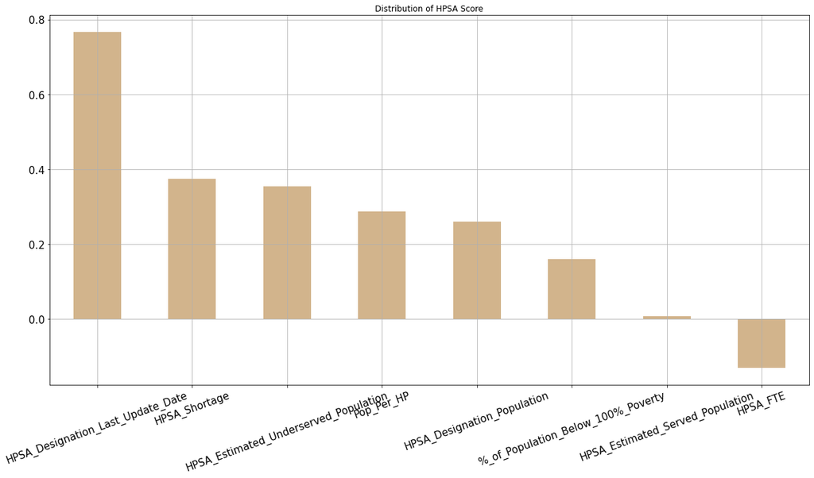

```python
# Correlation Plot with the Response variable
variables=hpsa.drop(['HPSA_Score'],axis=1)
variables.corrwith(hpsa['HPSA_Score']).sort_values(ascending=False).plot.bar(color = 'tan',figsize = (20, 10),
                                                                        fontsize = 15, rot = 20, grid = True)
plt.title('Distribution of HPSA Score')
```

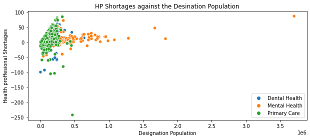

```python
#Create a scatter plot for the distribution of all three variables
fig= plt.figure(figsize=(10,4))
plt.xlabel("Designation Population")
plt.ylabel("Health proffesional Shortages")
plt.title("HP Shortages against the Desination Population")
sns.scatterplot(data = hpsa, x =hpsa['HPSA_Designation_Population'], y = hpsa['HPSA_Shortage'], hue=hpsa.HPSA_Discipline_Class.tolist())
```

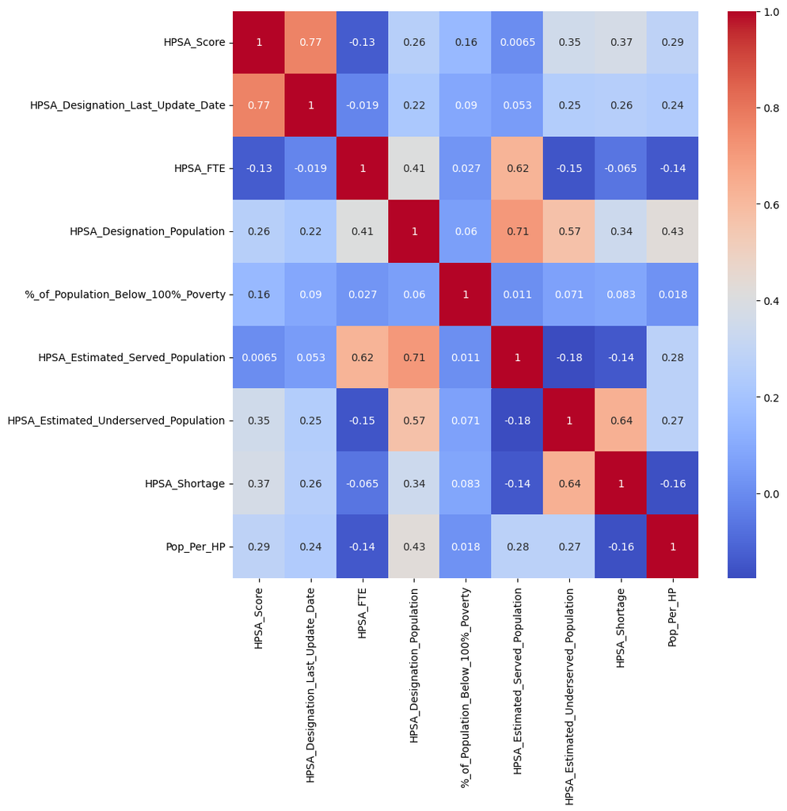

```python
plt.figure(figsize=(10,10),dpi=100)
sns.heatmap(hpsa.corr(),cmap="coolwarm",annot=True,linewidth=0)
plt.yticks(rotation=None)
```

# Data Preprocessing

## Categorical Encoding

All columns should be in numerical values for any mordel to train.Thus we need to convert all our categorical coulmns to numerical.

```python
#know the number of unique labels in all categorical columns
for col in hpsa.select_dtypes(include=['object']) :
    print(col, ':', len(hpsa[col].unique()), 'labels' )
```

```
HPSA_Name : 10145 labels
HPSA_ID : 14301 labels
Designation_Type : 3 labels
HPSA_Discipline_Class : 3 labels
HPSA_Status : 2 labels
HPSA_Population_Type : 14 labels
Rural_Status : 4 labels
Provider_Type : 4 labels
State_Name : 59 labels
U.S._-_Mexico_Border_100_Kilometer_Indicator : 2 labels
U.S._-_Mexico_Border_County_Indicator : 2 labels
```

### 1.Binary encoding

We can make use of binary encoding concept if columns having only two values and if they can be of type yes/no or similar.

```python
#cheque for unique values
print(hpsa['U.S._-_Mexico_Border_100_Kilometer_Indicator'].unique())
print(hpsa['U.S._-_Mexico_Border_County_Indicator'].unique())
print(hpsa['HPSA_Status'].unique())

#convert to numerical using basic replace method which is same as binary encoding
hpsa['U.S._-_Mexico_Border_100_Kilometer_Indicator']= hpsa['U.S._-_Mexico_Border_100_Kilometer_Indicator'].replace("N" , 0)
hpsa['U.S._-_Mexico_Border_100_Kilometer_Indicator']= hpsa['U.S._-_Mexico_Border_100_Kilometer_Indicator'].replace("Y", 1)
hpsa['U.S._-_Mexico_Border_County_Indicator']= hpsa['U.S._-_Mexico_Border_County_Indicator'].replace("N", 0)
hpsa['U.S._-_Mexico_Border_County_Indicator']= hpsa['U.S._-_Mexico_Border_County_Indicator'].replace("Y", 1)
hpsa['HPSA_Status']= hpsa['HPSA_Status'].replace("Withdrawn", 0)
hpsa['HPSA_Status']= hpsa['HPSA_Status'].replace("Designated", 1)

#cheque for unique values
print(hpsa['U.S._-_Mexico_Border_100_Kilometer_Indicator'].unique())
print(hpsa['U.S._-_Mexico_Border_County_Indicator'].unique())
print(hpsa['HPSA_Status'].unique())
```

```
['N' 'Y']
['N' 'Y']
['Designated' 'Withdrawn']
[0 1]
[0 1]
[1 0]
```

### 2. One Hot Encoding using get dummies method

We it is not possible to label the coloumns as ordinal values, then we can proceed with one hot encoding which creates columns for each of the categories present in the features. Here we need to take care of cardinality issue since having more number of categories in the feature lead to increase in dimensionality.

```python
# Convert'Provider_Type','Rural_Status','HPSA_Status','HPSA_Discipline_Class','Designation_Type','HPSA_Population_Type' using dummies encoding
cat_col=pd.get_dummies(hpsa[['Provider_Type','Rural_Status','HPSA_Discipline_Class','Designation_Type','HPSA_Population_Type']])
final_cat_col = cat_col.drop(['Provider_Type_Not Applicable','Rural_Status_Not Applicable','HPSA_Discipline_Class_Primary Care','Designation_Type_High Needs Geographic HPSA','HPSA_Population_Type_Other Population HPSA'],axis=1)
final_cat_col
```

|  | Provider_Type_Core Mental Health | Provider_Type_Psychiatrist | Provider_Type_Psychiatrist / Core Mental Health | Rural_Status_Non-Rural | Rural_Status_Partially Rural | Rural_Status_Rural | HPSA_Discipline_Class_Dental Health | HPSA_Discipline_Class_Mental Health | Designation_Type_Geographic HPSA | Designation_Type_HPSA Population | ... | HPSA_Population_Type_Low Income Homeless Migrant Seasonal Worker Population HPSA | HPSA_Population_Type_Low Income Homeless Population HPSA | HPSA_Population_Type_Low Income Migrant Farmworker Population HPSA | HPSA_Population_Type_Low Income Migrant Seasonal Worker Population HPSA | HPSA_Population_Type_Low Income Population HPSA | HPSA_Population_Type_Medicaid Eligible Population HPSA | HPSA_Population_Type_Migrant Farmworker Population HPSA | HPSA_Population_Type_Migrant Seasonal Worker Population HPSA | HPSA_Population_Type_Migrant Seasonal Worker and Homeless Population HPSA | HPSA_Population_Type_Native American Population HPSA |
| --- | --- | --- | --- | --- | --- | --- | --- | --- | --- | --- | --- | --- | --- | --- | --- | --- | --- | --- | --- | --- | --- |
| 0 | 0 | 0 | 0 | 0 | 0 | 1 | 1 | 0 | 1 | 0 | ... | 0 | 0 | 0 | 0 | 0 | 0 | 0 | 0 | 0 | 0 |
| 1 | 0 | 0 | 0 | 0 | 0 | 1 | 1 | 0 | 1 | 0 | ... | 0 | 0 | 0 | 0 | 0 | 0 | 0 | 0 | 0 | 0 |
| 2 | 0 | 0 | 0 | 0 | 0 | 1 | 1 | 0 | 1 | 0 | ... | 0 | 0 | 0 | 0 | 0 | 0 | 0 | 0 | 0 | 0 |
| 3 | 0 | 0 | 0 | 0 | 0 | 1 | 1 | 0 | 1 | 0 | ... | 0 | 0 | 0 | 0 | 0 | 0 | 0 | 0 | 0 | 0 |
| 4 | 0 | 0 | 0 | 0 | 0 | 1 | 1 | 0 | 1 | 0 | ... | 0 | 0 | 0 | 0 | 0 | 0 | 0 | 0 | 0 | 0 |
| ... | ... | ... | ... | ... | ... | ... | ... | ... | ... | ... | ... | ... | ... | ... | ... | ... | ... | ... | ... | ... | ... |
| 95194 | 0 | 0 | 0 | 0 | 0 | 1 | 0 | 0 | 1 | 0 | ... | 0 | 0 | 0 | 0 | 0 | 0 | 0 | 0 | 0 | 0 |
| 95195 | 0 | 0 | 0 | 0 | 0 | 1 | 0 | 0 | 1 | 0 | ... | 0 | 0 | 0 | 0 | 0 | 0 | 0 | 0 | 0 | 0 |
| 95196 | 0 | 0 | 0 | 0 | 0 | 1 | 0 | 0 | 1 | 0 | ... | 0 | 0 | 0 | 0 | 0 | 0 | 0 | 0 | 0 | 0 |
| 95197 | 0 | 0 | 0 | 0 | 0 | 1 | 0 | 0 | 1 | 0 | ... | 0 | 0 | 0 | 0 | 0 | 0 | 0 | 0 | 0 | 0 |
| 95198 | 0 | 0 | 0 | 0 | 0 | 1 | 0 | 0 | 0 | 1 | ... | 0 | 0 | 0 | 0 | 0 | 1 | 0 | 0 | 0 | 0 |

95199 rows × 23 columns

### 3. Frequency encoding

Since columns are having higher categories, we will proceed with frequency encoding

```python
#Frequency encoding
state_count = hpsa.State_Name.value_counts().to_dict()
print(state_count)
hpsa['State_Name'] = hpsa['State_Name'].map(state_count)
hpsa['State_Name']
```

```
{'New York': 10287, 'California': 9790, 'Florida': 6374, 'Arizona': 5253, 'Illinois': 5160, 'Texas': 4221, 'Michigan': 4210, 'Pennsylvania': 3765, 'Nevada': 3686, 'Wisconsin': 3233, 'Minnesota': 3030, 'Washington': 2413, 'Missouri': 2194, 'Ohio': 2108, 'Maryland': 2079, 'Maine': 1904, 'Tennessee': 1…
```

```
0        2413
1        2413
2        2413
3        2413
4        2413
         ...
95194     116
95195     116
95196     116
95197     116
95198     116
Name: State_Name, Length: 95199, dtype: int64
```

```python
# Frequency encoding
HPSA_Name_count = hpsa.HPSA_Name.value_counts().to_dict()
hpsa['HPSA_Name'] = hpsa['HPSA_Name'].map(HPSA_Name_count)
hpsa['HPSA_Name']
```

```
0        6
1        6
2        6
3        6
4        6
        ..
95194    2
95195    3
95196    3
95197    2
95198    1
Name: HPSA_Name, Length: 95199, dtype: int64
```

```python
hpsa_pre_proceesed =pd.concat([hpsa,final_cat_col],axis='columns').drop(['Provider_Type','Rural_Status','HPSA_Discipline_Class','Designation_Type','HPSA_Population_Type'],axis='columns')
hpsa_pre_proceesed.shape
hpsa_pre_proceesed = hpsa_pre_proceesed.reset_index(drop=True)
```

# Feature Scaling

Now we need to scale all features so that we can normalize/standardize the data.This means we are bringing all features to a common scale

```python
hpsa_pre_proceesed.describe()
```

|  | HPSA_Name | HPSA_Score | HPSA_Status | HPSA_Designation_Last_Update_Date | HPSA_FTE | HPSA_Designation_Population | %_of_Population_Below_100%_Poverty | HPSA_Estimated_Served_Population | HPSA_Estimated_Underserved_Population | HPSA_Shortage | ... | HPSA_Population_Type_Low Income Homeless Migrant Seasonal Worker Population HPSA | HPSA_Population_Type_Low Income Homeless Population HPSA | HPSA_Population_Type_Low Income Migrant Farmworker Population HPSA | HPSA_Population_Type_Low Income Migrant Seasonal Worker Population HPSA | HPSA_Population_Type_Low Income Population HPSA | HPSA_Population_Type_Medicaid Eligible Population HPSA | HPSA_Population_Type_Migrant Farmworker Population HPSA | HPSA_Population_Type_Migrant Seasonal Worker Population HPSA | HPSA_Population_Type_Migrant Seasonal Worker and Homeless Population HPSA | HPSA_Population_Type_Native American Population HPSA |
| --- | --- | --- | --- | --- | --- | --- | --- | --- | --- | --- | --- | --- | --- | --- | --- | --- | --- | --- | --- | --- | --- |
| count | 95199.000000 | 95199.000000 | 95199.000000 | 9.519900e+04 | 95199.000000 | 9.519900e+04 | 95199.000000 | 9.519900e+04 | 9.519900e+04 | 95199.000000 | ... | 95199.000000 | 95199.000000 | 95199.000000 | 95199.000000 | 95199.000000 | 95199.000000 | 95199.000000 | 95199.000000 | 95199.000000 | 95199.000000 |
| mean | 52.404300 | 11.141031 | 0.351285 | 2.015098e+07 | 7.369339 | 8.284699e+04 | 17.323080 | 4.020396e+04 | 4.264303e+04 | 7.897779 | ... | 0.000609 | 0.007878 | 0.012395 | 0.000830 | 0.439500 | 0.113163 | 0.000357 | 0.001765 | 0.000011 | 0.004254 |
| std | 69.347761 | 7.039100 | 0.477374 | 1.015237e+05 | 13.368902 | 1.083721e+05 | 25.145906 | 9.028383e+04 | 7.791430e+04 | 12.594647 | ... | 0.024676 | 0.088410 | 0.110642 | 0.028795 | 0.496329 | 0.316794 | 0.018895 | 0.041972 | 0.003241 | 0.065086 |
| min | 1.000000 | 0.000000 | 0.000000 | 1.979121e+07 | 0.000000 | 1.000000e+00 | 0.000000 | 0.000000e+00 | -1.397769e+06 | -242.682571 | ... | 0.000000 | 0.000000 | 0.000000 | 0.000000 | 0.000000 | 0.000000 | 0.000000 | 0.000000 | 0.000000 | 0.000000 |
| 25% | 12.000000 | 6.000000 | 0.000000 | 2.013041e+07 | 0.710000 | 1.593100e+04 | 9.500000 | 3.500000e+03 | 4.426000e+03 | 0.995350 | ... | 0.000000 | 0.000000 | 0.000000 | 0.000000 | 0.000000 | 0.000000 | 0.000000 | 0.000000 | 0.000000 | 0.000000 |
| 50% | 28.000000 | 13.000000 | 0.000000 | 2.020062e+07 | 3.000000 | 4.777600e+04 | 16.400000 | 1.450000e+04 | 2.096800e+04 | 3.556000 | ... | 0.000000 | 0.000000 | 0.000000 | 0.000000 | 0.000000 | 0.000000 | 0.000000 | 0.000000 | 0.000000 | 0.000000 |
| 75% | 64.000000 | 17.000000 | 1.000000 | 2.021091e+07 | 8.113200 | 1.118130e+05 | 24.400000 | 4.076000e+04 | 6.392100e+04 | 10.769000 | ... | 0.000000 | 0.000000 | 0.000000 | 0.000000 | 1.000000 | 0.000000 | 0.000000 | 0.000000 | 0.000000 | 0.000000 |
| max | 491.000000 | 25.000000 | 1.000000 | 2.022032e+07 | 376.000000 | 3.702339e+06 | 6616.000000 | 1.599800e+06 | 2.592339e+06 | 86.411300 | ... | 1.000000 | 1.000000 | 1.000000 | 1.000000 | 1.000000 | 1.000000 | 1.000000 | 1.000000 | 1.000000 | 1.000000 |

8 rows × 37 columns

```python
hpsa_pre_proceesed.Pop_Per_HP.describe()
```

```
count    95199.000000
mean      7461.475436
std       7878.371693
min       3000.000000
25%       3000.000000
50%       3500.000000
75%       5000.000000
max      30000.000000
Name: Pop_Per_HP, dtype: float64
```

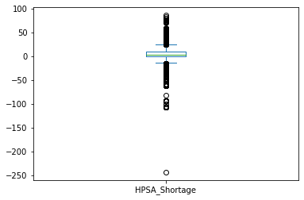

```python
hpsa_pre_proceesed['HPSA_Shortage'].plot.box()
```

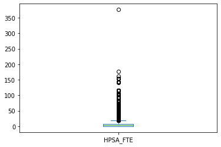

```python
hpsa_pre_proceesed['HPSA_FTE'].plot.box()
```

```python
from sklearn.preprocessing import RobustScaler
from sklearn import preprocessing
x=hpsa_pre_proceesed[['HPSA_Name',
                      'HPSA_Designation_Last_Update_Date',
                      'HPSA_FTE',
                      'HPSA_Designation_Population',
                      '%_of_Population_Below_100%_Poverty',
                      'HPSA_Estimated_Served_Population',
                      'HPSA_Estimated_Underserved_Population',
                      'HPSA_Shortage',
                      'State_Name',
                      'Pop_Per_HP']]

scaler = preprocessing.RobustScaler()
robust_df = scaler.fit_transform(x)
scaled_data = pd.DataFrame(robust_df, columns= [
                      'HPSA_Name',
                      'HPSA_Designation_Last_Update_Date',
                      'HPSA_FTE',
                      'HPSA_Designation_Population',
                      '%_of_Population_Below_100%_Poverty',
                      'HPSA_Estimated_Served_Population',
                      'HPSA_Estimated_Underserved_Population',
                      'HPSA_Shortage',
                      'State_Name',
                      'Pop_Per_HP'])
```

```python
not_scaled = hpsa_pre_proceesed.drop([
                      'HPSA_Name',
                      'HPSA_Designation_Last_Update_Date',
                      'HPSA_FTE',
                      'HPSA_Designation_Population',
                      '%_of_Population_Below_100%_Poverty',
                      'HPSA_Estimated_Served_Population',
                      'HPSA_Estimated_Underserved_Population',
                      'HPSA_Shortage',
                      'State_Name',
                      'Pop_Per_HP'],axis=1)
scaled_final = not_scaled.merge(scaled_data,left_index=True,right_index=True,how = "left")
```

```python
scaled_final
```

|  | HPSA_ID | HPSA_Score | HPSA_Status | U.S._-_Mexico_Border_100_Kilometer_Indicator | U.S._-_Mexico_Border_County_Indicator | Provider_Type_Core Mental Health | Provider_Type_Psychiatrist | Provider_Type_Psychiatrist / Core Mental Health | Rural_Status_Non-Rural | Rural_Status_Partially Rural | ... | HPSA_Name | HPSA_Designation_Last_Update_Date | HPSA_FTE | HPSA_Designation_Population | %_of_Population_Below_100%_Poverty | HPSA_Estimated_Served_Population | HPSA_Estimated_Underserved_Population | HPSA_Shortage | State_Name | Pop_Per_HP |
| --- | --- | --- | --- | --- | --- | --- | --- | --- | --- | --- | --- | --- | --- | --- | --- | --- | --- | --- | --- | --- | --- |
| 0 | 6538432701 | 20 | 1 | 0 | 0 | 0 | 0 | 0 | 0 | 0 | ... | -0.423077 | 0.127885 | -0.405230 | -0.346895 | 0.342282 | -0.389157 | -0.108463 | -0.066812 | -0.281081 | 0.75 |
| 1 | 6538432701 | 20 | 1 | 0 | 0 | 0 | 0 | 0 | 0 | 0 | ... | -0.423077 | 0.127885 | -0.405230 | -0.346895 | 0.342282 | -0.389157 | -0.108463 | -0.066812 | -0.281081 | 0.75 |
| 2 | 6538432701 | 20 | 1 | 0 | 0 | 0 | 0 | 0 | 0 | 0 | ... | -0.423077 | 0.127885 | -0.405230 | -0.346895 | 0.342282 | -0.389157 | -0.108463 | -0.066812 | -0.281081 | 0.75 |
| 3 | 6538432701 | 20 | 1 | 0 | 0 | 0 | 0 | 0 | 0 | 0 | ... | -0.423077 | 0.127885 | -0.405230 | -0.346895 | 0.342282 | -0.389157 | -0.108463 | -0.066812 | -0.281081 | 0.75 |
| 4 | 6538432701 | 20 | 1 | 0 | 0 | 0 | 0 | 0 | 0 | 0 | ... | -0.423077 | 0.127885 | -0.405230 | -0.346895 | 0.342282 | -0.389157 | -0.108463 | -0.066812 | -0.281081 | 0.75 |
| ... | ... | ... | ... | ... | ... | ... | ... | ... | ... | ... | ... | ... | ... | ... | ... | ... | ... | ... | ... | ... | ... |
| 95194 | 1029035922 | 15 | 1 | 0 | 0 | 0 | 0 | 0 | 0 | 0 | ... | -0.500000 | 0.126767 | -0.405230 | -0.412570 | -0.375839 | -0.389157 | -0.214304 | -0.123598 | -0.758628 | 0.00 |
| 95195 | 1028990664 | 17 | 1 | 0 | 0 | 0 | 0 | 0 | 0 | 0 | ... | -0.480769 | 0.126767 | -0.405230 | -0.397603 | 0.342282 | -0.389157 | -0.190184 | -0.081648 | -0.758628 | 0.00 |
| 95196 | 1028855282 | 13 | 1 | 0 | 0 | 0 | 0 | 0 | 0 | 0 | ... | -0.480769 | 0.127885 | -0.405230 | -0.475981 | -0.409396 | -0.389157 | -0.316497 | -0.301335 | -0.758628 | 0.00 |
| 95197 | 1026580765 | 10 | 1 | 0 | 0 | 0 | 0 | 0 | 0 | 0 | ... | -0.500000 | 0.244702 | -0.202615 | -0.441397 | -0.644295 | -0.248256 | -0.349004 | -0.357872 | -0.758628 | 0.00 |
| 95198 | 1026530384 | 13 | 1 | 0 | 0 | 0 | 0 | 0 | 0 | 0 | ... | -0.519231 | 0.243509 | -0.070780 | -0.272335 | -0.295302 | -0.189801 | -0.113152 | 0.121688 | -0.758628 | -0.25 |

95199 rows × 38 columns

## Building of the Model

```python
from sklearn.model_selection import train_test_split
from sklearn.tree import DecisionTreeClassifier
from sklearn.metrics import confusion_matrix,accuracy_score,classification_report
from sklearn.metrics import confusion_matrix
import statsmodels.api as sm
from sklearn.metrics import classification_report
from sklearn import metrics
```

```python
# Feature columns
X =scaled_final.drop(['HPSA_Score'],axis=1)
#Target column
Y = scaled_final['HPSA_Score']
#splitting train and test data
X_train1, X_test, y_train1, y_test = train_test_split(X, Y, test_size = 0.2, random_state = 0)
X_train, X_val, y_train, y_val = train_test_split(X_train1, y_train1, test_size = 0.2, random_state = 0)
```

```python
##seperating dependent and independent variables
Id_train  = X_train['HPSA_ID']
X_train =X_train.drop(['HPSA_ID'],axis=1)

Id_test  = X_test['HPSA_ID']
X_test =X_test.drop(['HPSA_ID'],axis=1)

Id_val  = X_val['HPSA_ID']
X_val = X_val.drop(['HPSA_ID'],axis=1)
```

```python
print(X_train.shape)
print(X_test.shape)
print(X_val.shape)
print(y_train.shape)
print(y_test.shape)
print(y_val.shape)
```

```
(60927, 36)
(19040, 36)
(15232, 36)
(60927,)
(19040,)
(15232,)
```

```python
from sklearn.ensemble import RandomForestClassifier
rfc = RandomForestClassifier(n_estimators=100)
rfc.fit(X_train,y_train)
```

```
RandomForestClassifier()
```

```python
y_pred = rfc.predict(X_val)
y_pred
```

```
array([16,  0,  6, ..., 15, 19, 17])
```

```python
val_acc_score = accuracy_score(y_val,y_pred)
val_acc_score
```

```
0.9433429621848739
```

```python
confusion_matrix(y_val, y_pred)
```

```
array([[3644,    0,    0,    0,    0,    0,    1,    0,    0,    0,    1,
           0,    0,    0,    0,    0,    0,    0,    0,    0,    0,    0,
           0,    0,    0,    0],
       [   0,    0,    0,    0,    0,    0,    0,    0,    0,    0,    0,
           0,    0,    0,    0,    0,    0,    0,    0,    0,    0,    0,
           0,    0,    0,    0],
       [   0,    0,    1,    0,    0,    0,    0,    0,    0,    1,    0,
           0,    1,    0,    0,    0,    0,    0,    0,    0,    0,    0,
           0,    0,    0,    0],
       [   0,    0,    0,   10,    0,    0,    0,    0,    2,    0,    1,
           0,    0,    0,    0,    0,    0,    0,    0,    0,    0,    0,
           0,    0,    0,    0],
       [   0,    0,    1,    0,   46,    1,    1,    0,    0,    1,    0,
           2,    0,    0,    0,    0,    0,    0,    0,    0,    0,    0,
           0,    0,    0,    0],
       [   0,    0,    0,    0,    0,   42,    3,    4,    2,    1,    0,
           0,    3,    2,    0,    0,    0,    0,    0,    0,    0,    0,
           0,    0,    0,    0],
       [   0,    1,    0,    0,    0,    0,  167,    4,    1,    3,    0,
           0,    0,    0,    0,    0,    0,    0,    0,    0,    0,    0,
           0,    0,    0,    0],
       [   0,    0,    0,    0,    0,    0,    1,  140,    3,    3,    3,
           3,    2,    2,    0,    1,    1,    0,    0,    0,    0,    0,
           0,    0,    0,    0],
       [   0,    0,    0,    1,    0,    0,    1,    6,  230,    6,   10,
           2,    3,    1,    1,    0,    0,    0,    0,    1,    0,    0,
           0,    0,    0,    0],
       [   1,    0,    0,    0,    0,    2,    2,    4,    4,  394,    8,
           5,    5,    1,    3,    0,    2,    2,    0,    0,    0,    0,
           0,    0,    0,    0],
       [   0,    0,    0,    0,    0,    0,    1,    5,    9,    8,  460,
           7,    5,    7,    6,    2,    2,    0,    0,    0,    0,    0,
           0,    0,    0,    0],
       [   1,    0,    0,    0,    1,    0,    0,    2,    1,    5,    7,
         707,   23,   11,    5,    3,    3,    0,    0,    0,    0,    0,
           0,    0,    0,    0],
       [   0,    0,    0,    0,    0,    0,    1,    2,    1,    5,    7,
          18,  660,   14,    7,    9,    3,    2,    0,    2,    0,    0,
           0,    0,    0,    0],
       [   0,    0,    0,    0,    0,    0,    0,    0,    3,    3,    2,
```

[output cut: 23 more lines]

```
       [   0,    0,    0,    0,    0,    0,    0,    0,    0,    0,    0,
           0,    1,    0,    0,    0,    1,    2,    2,    4,    1,  315,
           0,    1,    1,    0],
       [   0,    0,    0,    0,    0,    0,    0,    0,    0,    0,    0,
           0,    0,    0,    0,    0,    0,    0,    1,    2,    0,    1,
          34,    0,    0,    0],
       [   0,    0,    0,    0,    0,    0,    0,    0,    0,    0,    0,
           0,    0,    0,    0,    0,    0,    0,    0,    1,    0,    0,
           0,   42,    0,    0],
       [   0,    0,    0,    0,    0,    0,    0,    0,    0,    0,    0,
           0,    0,    0,    0,    0,    0,    0,    0,    0,    0,    0,
           0,    0,    8,    0],
       [   0,    0,    0,    0,    0,    0,    0,    0,    0,    0,    0,
           0,    0,    0,    0,    0,    0,    0,    0,    0,    0,    0,
           0,    0,    0,   14]])
```

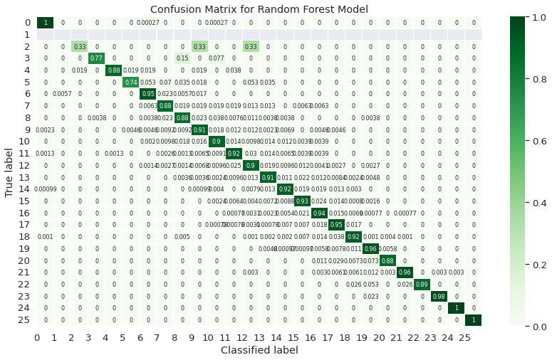

```python
# Get and reshape confusion matrix data
matrix = confusion_matrix(y_val, y_pred)
matrix = matrix.astype('float') / matrix.sum(axis=1)[:, np.newaxis]

# Build the plot
plt.figure(figsize=(14,8))
sns.set(font_scale=1.2)
sns.heatmap(matrix, annot=True, annot_kws={'size':8},
            cmap=plt.cm.Greens, linewidths=0.1)

# Add labels to the plot
class_names = ['0','1','2','3','4','5','6','7','8','9','10','11','12','13','14','15','16','17','18','19','20','21','22','23','24','25']
tick_marks = np.arange(len(class_names))
tick_marks2 = tick_marks+0.5
plt.xticks(tick_marks, class_names, rotation=0)
plt.yticks(tick_marks2, class_names, rotation=0)
plt.xlabel('Classified label')
plt.ylabel('True label')
plt.title('Confusion Matrix for Random Forest Model')
plt.show()
```

```python
print(classification_report(y_val, y_pred))
```

```
              precision    recall  f1-score   support

           0       1.00      1.00      1.00      3646
           1       0.00      0.00      0.00         0
           2       0.50      0.33      0.40         3
           3       0.91      0.77      0.83        13
           4       0.98      0.88      0.93        52
           5       0.93      0.74      0.82        57
           6       0.94      0.95      0.94       176
           7       0.84      0.88      0.86       159
           8       0.88      0.88      0.88       262
           9       0.91      0.91      0.91       433
          10       0.91      0.90      0.90       512
          11       0.93      0.92      0.92       769
          12       0.90      0.90      0.90       731
```

[output cut: 17 more lines]

# Feature Importance

```python
feature_imp = pd.Series(rfc.feature_importances_,index=X_train.columns).sort_values(ascending=False)
feature_imp
```

```
HPSA_Designation_Last_Update_Date                                                   0.197904
%_of_Population_Below_100%_Poverty                                                  0.104546
HPSA_Estimated_Underserved_Population                                               0.093516
HPSA_Shortage                                                                       0.087209
HPSA_Name                                                                           0.086904
HPSA_Designation_Population                                                         0.083534
HPSA_FTE                                                                            0.074881
HPSA_Estimated_Served_Population                                                    0.073881
State_Name                                                                          0.055361
HPSA_Status                                                                         0.024848
Pop_Per_HP                                                                          0.018380
Designation_Type_Geographic HPSA                                                    0.014057
Rural_Status_Non-Rural                                                              0.009970
HPSA_Discipline_Class_Dental Health                                                 0.009932
HPSA_Population_Type_Low Income Population HPSA                                     0.009512
Rural_Status_Rural                                                                  0.008754
Designation_Type_HPSA Population                                                    0.007105
HPSA_Population_Type_Medicaid Eligible Population HPSA                              0.006650
HPSA_Discipline_Class_Mental Health                                                 0.006302
HPSA_Population_Type_Geographic Population                                          0.006276
Provider_Type_Psychiatrist                                                          0.004908
U.S._-_Mexico_Border_County_Indicator                                               0.003910
U.S._-_Mexico_Border_100_Kilometer_Indicator                                        0.003380
HPSA_Population_Type_Low Income Migrant Farmworker Population HPSA                  0.001788
Rural_Status_Partially Rural                                                        0.001470
HPSA_Population_Type_Low Income Homeless Migrant Farmworker Population HPSA         0.001342
Provider_Type_Psychiatrist / Core Mental Health                                     0.001174
HPSA_Population_Type_Low Income Homeless Population HPSA                            0.001034
HPSA_Population_Type_Homeless Population HPSA                                       0.000494
HPSA_Population_Type_Migrant Seasonal Worker Population HPSA                        0.000313
HPSA_Population_Type_Native American Population HPSA                                0.000219
HPSA_Population_Type_Low Income Homeless Migrant Seasonal Worker Population HPSA    0.000150
HPSA_Population_Type_Low Income Migrant Seasonal Worker Population HPSA             0.000147
Provider_Type_Core Mental Health                                                    0.000144
HPSA_Population_Type_Migrant Farmworker Population HPSA                             0.000006
HPSA_Population_Type_Migrant Seasonal Worker and Homeless Population HPSA           0.000000
dtype: float64
```

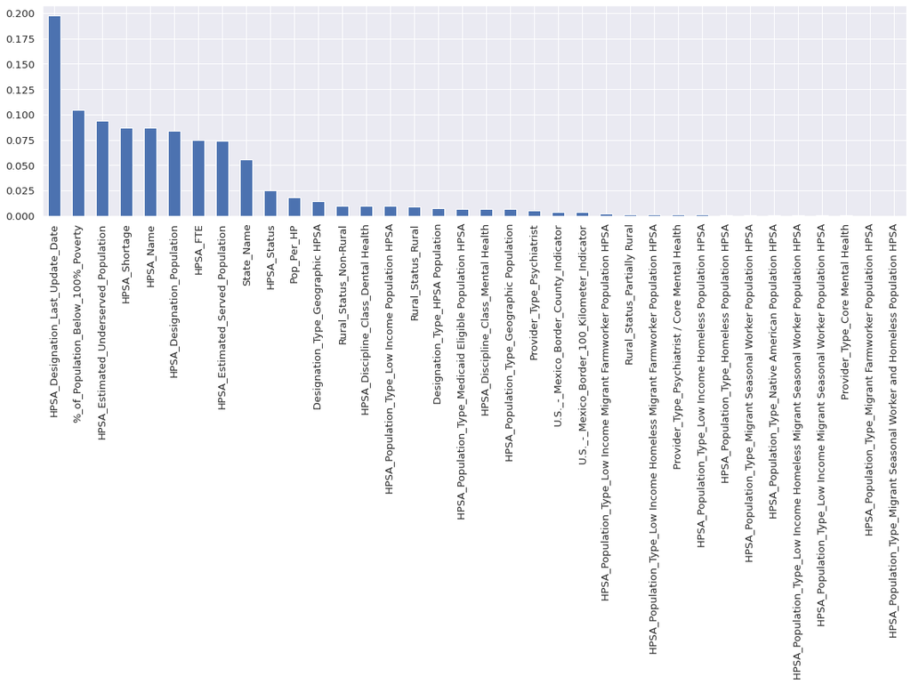

```python
Feature_imp_graph = feature_imp.plot.bar(figsize=(20,5))
```

## Rebuild the model using important features

```python
# take only important features
X_new=scaled_final[['HPSA_Designation_Last_Update_Date',
                '%_of_Population_Below_100%_Poverty',
                'HPSA_Estimated_Underserved_Population',
                'HPSA_Name',
                'HPSA_Shortage',
                'HPSA_Designation_Population',
                'HPSA_FTE',
                'HPSA_Estimated_Served_Population',
                'State_Name',
                'HPSA_Status',
                'Pop_Per_HP',
                'Designation_Type_Geographic HPSA',
                'Rural_Status_Non-Rural',
                'HPSA_Discipline_Class_Dental Health',
                'HPSA_Population_Type_Low Income Population HPSA',
                'HPSA_ID']]
y_new=scaled_final['HPSA_Score']


# Split dataset into training set and test set - 70% training and 30% test
X_train_new, X_test_new, y_train_new, y_test_new = train_test_split(X_new, y_new, test_size=0.30, random_state=5)

Id_train_new  = X_train_new['HPSA_ID']
X_train_new =X_train_new.drop(['HPSA_ID'],axis=1)

Id_test_new  = X_test_new['HPSA_ID']
X_test_new =X_test_new.drop(['HPSA_ID'],axis=1)
```

```python
from sklearn.ensemble import RandomForestClassifier
rfc1 = RandomForestClassifier(bootstrap=True, class_weight=None, criterion='gini',
            max_depth=None, max_features='auto', max_leaf_nodes=None,
            min_samples_leaf=1, min_samples_split=2,
            min_weight_fraction_leaf=0.0, n_estimators=100, n_jobs=1,
            oob_score=False, random_state=None, verbose=0,
            warm_start=False)
rfc1.fit(X_train_new,y_train_new)
```

```
RandomForestClassifier(n_jobs=1)
```

```python
y_pred_new = rfc1.predict(X_test_new)
```

```python
acc_score = accuracy_score(y_test_new,y_pred_new)
acc_score
```

```
0.9442577030812325
```

```python
print(X_test_new.shape)
print(y_test_new.shape)
print(y_pred_new.shape)
print(Id_test_new.shape)
```

```
(28560, 15)
(28560,)
(28560,)
(28560,)
```

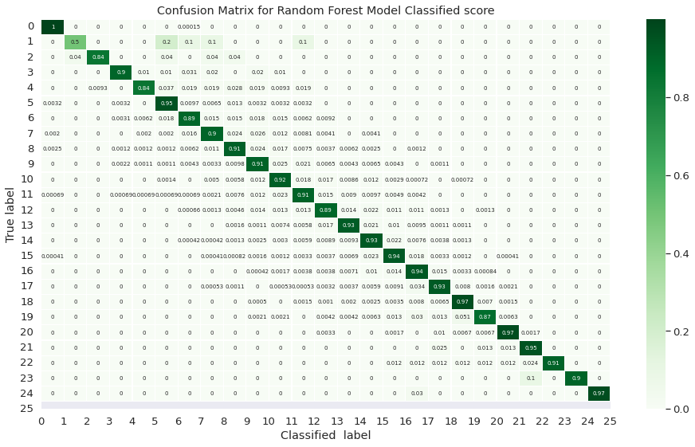

```python
# Get and reshape confusion matrix data
matrix = confusion_matrix(y_test_new, y_pred_new)
matrix = matrix.astype('float') / matrix.sum(axis=1)[:, np.newaxis]

# Build the plot
plt.figure(figsize=(16,9))
sns.set(font_scale=1.2)
sns.heatmap(matrix, annot=True, annot_kws={'size':7},
            cmap=plt.cm.Greens, linewidths=0.2)

# Add labels to the plot
class_names = ['0','1','2','3','4','5','6','7','8','9','10','11','12','13','14','15','16','17','18','19','20','21','22','23','24','25']
tick_marks = np.arange(len(class_names))
tick_marks2 = tick_marks + 0.5
plt.xticks(tick_marks, class_names, rotation=0)
plt.yticks(tick_marks2, class_names, rotation=0)
plt.xlabel('Classified  label')
plt.ylabel('True label')
plt.title('Confusion Matrix for Random Forest Model Classified score')
plt.show()
```

The confusion matrix depicts accuracy between the true label and Classified label (Score is the label in our case). Most of our labels were Classified correctly with accuracy above 90%. Over all accuracy is 94%

```python
final_results = pd.concat([y_test_new, Id_test_new], axis ='columns').dropna().reset_index(drop=True)
```

```python
final_results['Classified_score'] = y_pred_new
```

```python
final_results[['HPSA_ID','HPSA_Score','Classified_score']].reset_index(drop=True)
```

|  | HPSA_ID | HPSA_Score | Classified_score |
| --- | --- | --- | --- |
| 0 | 1429994265 | 0 | 0 |
| 1 | 1299992935 | 14 | 14 |
| 2 | 6124047506 | 16 | 16 |
| 3 | 7365615145 | 11 | 11 |
| 4 | 1065493371 | 11 | 11 |
| ... | ... | ... | ... |
| 28555 | 136999365F | 14 | 14 |
| 28556 | 642999426L | 10 | 10 |
| 28557 | 1123052883 | 16 | 15 |
| 28558 | 136999364P | 17 | 17 |
| 28559 | 1469994606 | 0 | 0 |

28560 rows × 3 columns

## Conclusion

Random Forest Classifier Model is accurate enough in Classifying the HPSA score with 94% accuracy.

```python
%%shell
ipython nbconvert --to html  HSPA_Classififcation.ipynb
```